# 20 - Gene expression x byssal thread mechanics correlation (paired samples)

Byssus expression analysis

2026-09-29

# Purpose

A subset of *M. trossulus* that were mechanically tested for byssal plaque attachment were also sampled for Tag-seq. This script links those two datasets at the level of the individual animal and asks: **does foot (or gill) gene expression at day 3 of stress covary with plaque attachment performance?**

It produces:

1. A paired-sample manifest (exactly which animals/samples were used).
2. Per-gene association statistics: one baseline-adjusted regression (ANCOVA) of each animal’s day-3 level of a mechanical metric on its expression, controlling for treatment and for the animal’s own pre-exposure level, with multiple-testing correction.
3. Two gene universes: a biologically motivated **candidate set** (byssal / collagen / HSP / HIF / peroxidase / aminoacyl-tRNA-synthetase genes) and the **data-driven DEG union** (genes already found to respond to any stressor).
4. Diagnostic plots (top-hit scatterplots, candidate-gene correlation heatmap).

> **READ THIS FIRST - power.** The paired set is small, even with the full thread dataset and the day-3 control arm included; the baseline-adjusted test uses only the animals with a baseline, and within any single arm n is smaller still. This analysis is **exploratory and hypothesis-generating, not confirmatory.** Treat raw p-values as ranking signals, expect few or no hits to survive FDR correction, and do not write causal language from it. Tag-seq sampling was destructive (foot/gill removed), so expression and the *post-stress* threads come from the same animal at the same timepoint; this is association, not a demonstrated mechanism.

> **The search is declared here, not in the write-up.** `METRICS` below names the metrics that form the confirmatory family (candidate genes x primary metrics); every other metric is labelled `exploratory` in every output table (`tier` column), and `q_family` is the BH correction over each gene set x tier family, so the primary family carries its own search-corrected q.

> **Which metric to read first.** **Peak force and plaque area** are tested separately as well as through their ratio, since adhesion mixes the two (`thread-strength/01_code/4_decompose_adhesion.Rmd` decomposes it the same way) and a gene associated with plaque size can be invisible against the ratio. `max_force` and `pad_area` are the primary targets here; `adhesion_kpa` is retained as the material-strength readout. Every metric is tested as the animal’s day-3 level with its own baseline level as a covariate, so “does expression track attachment” is asked net of where the animal started.

# 0. Configuration

```r
## ---- analysis options ---------------------------------------------------------------
## Tissue comes from the knit parameter (`params$tissue`, default "F") so the same script
## serves foot and gill; the driver 24-run_gene_mechanics_by_tissue.Rmd renders both.
## When run chunk-by-chunk outside a knit, `params` may not exist; fall back to foot.
TISSUE <- if (exists("params") && !is.null(params$tissue)) toupper(params$tissue) else "F"
stopifnot(TISSUE %in% c("F", "G"))
MIN_COUNT     <- 5            # gene kept if count > MIN_COUNT in >= 1/3 of paired samples
FDR_ALPHA     <- 0.10         # BH threshold for flagging
## Detection floor. A gene whose VST value sits at the floor (zero counts) in many paired
## animals gives an association driven by presence/absence, not by expression level. Every
## tested gene gets frac_at_floor and floor_flag (exclude > FLOOR_EXCLUDE, caution >
## FLOOR_CAUTION); with EXCLUDE_FLOOR_GENES = TRUE the `exclude` genes are dropped from the
## candidate and DEG-union families BEFORE testing, so BH runs on the family that can be
## interpreted. They stay listed (floor_flag, tested = FALSE) and they still contribute to
## script 21's module scores.
FLOOR_EXCLUDE <- 0.40
FLOOR_CAUTION <- 0.20
EXCLUDE_FLOOR_GENES <- TRUE
INCLUDE_CONTROL_ARM <- TRUE   # TRUE = the day-3 common-garden control animals (T126-T137)
                              #        are part of the paired set, as a fourth treatment
                              #        level. They have foot RNA, day-3 threads and baseline
                              #        threads. Their own three-day trajectory is the null a
                              #        stress-specific expression signal must beat.
                              # FALSE = stressor arms only.
USE_SECRETION_STATE <- FALSE  # TRUE = add each animal's byssal SECRETION STATE (on/off; the
                              #        foot plaque-protein module, computed per foot sample by
                              #        differential-expression/01_code/01_7-secretion_state.Rmd
                              #        and read from SECRETION_STATE_FILE) as a nuisance
                              #        covariate in every per-gene regression, beside
                              #        treatment. Any candidate that co-varies with that
                              #        module would otherwise pick up secretion state, not
                              #        mechanics.
                              #        Script 21 reads the same choice from metrics_config.
                              #        Gill animals take the state of their own foot sample.
                              # FALSE (default) = treatment is the only covariate; the state
                              #        is still joined into the manifest for inspection when
                              #        the file exists, but enters no model.

## ---- mechanical metrics and the reported test ----------------------------------------
## One test per gene x metric: an analysis of covariance of the animal's day-3 level on
## its expression, with the arm [and the secretion state] and the animal's OWN pre-exposure
## level as covariates:
##     level_day3 ~ expression + treatment [+ secretion_state] + level_baseline
## Force, area and adhesion are modelled on the LOG scale (per-animal geometric means of
## the plaques; multiplicative, right-skewed quantities), extension on its raw scale. Animals
## without baseline threads are not in the fits.
## `tier`: force and area are the pre-declared confirmatory family (candidate genes x
## primary metrics); adhesion (their ratio) and extension are exploratory. Every output
## table carries the tier, and `q_family` corrects within each gene set x tier.
## Order here is the reporting order. Force and area first, deliberately (see above).
METRICS <- data.frame(
  metric = c("max_force",      "pad_area",           "adhesion_kpa",   "max_displacement"),
  scale  = c("log",            "log",                "log",            "raw"),
  tier   = c("primary",        "primary",            "exploratory",    "exploratory"),
  label  = c("Peak force (N)", "Plaque area (mm^2)", "Adhesion (kPa)", "Extension at break (mm)"),
  stringsAsFactors = FALSE)
metrics         <- METRICS$metric
PRIMARY_METRICS <- METRICS$metric[METRICS$tier == "primary"]
scale_of <- function(m) METRICS$scale[match(m, METRICS$metric)]
tier_of  <- function(m) METRICS$tier[match(m, METRICS$metric)]
label_of <- function(m) METRICS$label[match(m, METRICS$metric)]
on_scale <- function(m, v) if (scale_of(m) == "log") log(v) else v    # a value on its model scale

## ---- candidate gene keywords (regex, case-insensitive) ------------------------------
## Grouped by biology; edit freely. Matched against UniProt "protein_name".
CANDIDATE_KEYWORDS <- paste(
  # byssal structural / adhesive proteins (plaque proteins, thread core, cuticle)
  "byss", "foot protein", "Mefp", "adhesive plaque", "polyphenolic",
  "byssal protein-", "preCol", "precollagen", "byssal EP", "ACDC", "byssal tyrosinase",
  "byssal peroxidase", "byssal HSP", "byssal calumenin", "byssal protease inhibitor",
  # collagens / preCols (byssal thread core)
  "collagen",
  # plaque-curing / cross-linking enzymes
  "tyrosinase", "peroxidase", "amine oxidase", "catechol oxidase", "lysyl oxidase",
  # proteostasis / heat-shock
  "heat shock", "Hsp", "stress-70", "BiP", "chaperone",
  "endoplasmic reticulum chaperone", "hypoxia up-regulated",
  # hypoxia signalling
  "hypoxia-inducible", "Egl nine", "prolyl 4-hydroxylase", "prolyl hydroxylase",
  # translational machinery (aminoacyl-tRNA synthetases)
  "--tRNA", "tRNA ligase", "aminoacyl",
  # oxidative stress / detox
  "superoxide", "glutathione", "catalase", "peroxiredoxin", "dual oxidase",
  sep = "|"
)
```

```r
# Get the correct Bioconductor repository link for your R version
# bioc_version <- BiocManager::version()
# bioc_repo <- paste0("https://bioconductor.org/packages/", bioc_version, "/bioc")
#
# # Install DESeq2 directly as a standard package
# install.packages("GenomeInfoDbData", repos = c(Bioc = bioc_repo, CRAN = "https://cloud.r-project.org"))
# install.packages("DESeq2", repos = c(Bioc = bioc_repo, CRAN = "https://cloud.r-project.org"))
```

```r
## Load Packages
## DESeq2 first, tidyverse LAST: S4Vectors/IRanges (pulled in by DESeq2) mask dplyr's
## rename(), count(), first() and desc(). Loading tidyverse after them restores dplyr's.
load.lib <- c("DESeq2","readxl","openxlsx","here","tidyverse")
install.lib <- load.lib[!load.lib %in% installed.packages()]
for(lib in install.lib) install.packages(lib, dependencies = TRUE)
sapply(load.lib, require, character = TRUE)
```

```
##    DESeq2    readxl  openxlsx      here tidyverse
##      TRUE      TRUE      TRUE      TRUE      TRUE
```

```r
`%||%` <- function(a, b) if (is.null(a) || length(a) == 0) b else a
```

```r
## Resolve the repository root (the folder holding the analysis subfolders), robust to whether
## this is knit from gene-mechanics-correlation.Rproj or the top-level project.
find_repo_root <- function(start = here::here()) {
  d <- normalizePath(start, winslash = "/")
  for (i in 1:6) {
    if (all(dir.exists(file.path(d, c("differential-expression", "thread-strength"))))) return(d)
    d <- dirname(d)
  }
  stop("Repo root not found: need a parent containing differential-expression/ and thread-strength/.")
}
repo_root   <- find_repo_root()
DE_DIR      <- file.path(repo_root, "differential-expression")          # expression-side inputs
## The curated thread table produced by thread-strength scripts 1-2 and hand-reviewed; and
## the per-animal response classification produced by thread-strength script 4.
THREAD_FILE   <- file.path(repo_root, "thread-strength", "03_analyses", "thread-summary.xlsx")
RESPONSE_FILE <- file.path(repo_root, "thread-strength", "03_analyses", "04_decompose-adhesion",
                           "mussel_response_classification.csv")
OUT_DIR     <- file.path(repo_root, "gene-mechanics-correlation", "03_analyses", "gene_mechanics")
dir.create(OUT_DIR, showWarnings = FALSE, recursive = TRUE)
## Per-animal byssal secretion state (differential-expression script 01_7). Joined into the
## manifest whenever it exists; used as a covariate only when USE_SECRETION_STATE is TRUE.
SECRETION_STATE_FILE <- file.path(DE_DIR, "02_data", "secretion_state.csv")
## ---- annotation map and candidate universe ------------------------------------------
## CANDIDATE_ANNOTATION:
##   "genome" (default) = every gene in the count matrix is annotated with its best UniProt
##            hit (highest bitscore) from the genome-wide BLAST table MASTER_ANNOT_FILE, so
##            any EXPRESSED gene whose name matches CANDIDATE_KEYWORDS is a candidate.
##   "TC_DEG" = only genes that carry a name in the treatment-vs-control DEG tables
##            (GOterms_genome/*_sigs_ID.csv) can be candidates, plus the byssal structural
##            genes. That was the behaviour until 2026-09-18; it made "already a DEG in some
##            contrast" a hidden entry condition for the candidate family.
## The two sources agree on the name for 947 of the 969 DEG-annotated genes; the 22 that
## differ are LOCs whose transcripts hit different proteins, and the genome map takes the
## highest-scoring hit (the same rule script 23 uses).
## CANDIDATE_MAX_EVALUE / CANDIDATE_MIN_PIDENT: BLAST-quality floor for a gene to be a
## candidate under "genome" (the map itself keeps every hit, with pident and evalue columns).
## On this table every keyword match already has evalue < 1e-10; pident >= 40 is script
## 23's HI_CONF_ONLY rule.
CANDIDATE_ANNOTATION <- "genome"
CANDIDATE_MAX_EVALUE <- 1e-10
CANDIDATE_MIN_PIDENT <- 0
MASTER_ANNOT_FILE <- file.path(repo_root, "blast", "03_analyses", "genome-foot", "LOC_GO_list.txt")
BYSSAL_STRUCTURAL_REGEX <- paste("foot protein", "adhesive plaque", "polyphenolic", "byssal protein-",
                                 "preCol", "precollagen", "byssal EP", "ACDC", "byssal tyrosinase",
                                 sep = "|")

if (!file.exists(THREAD_FILE))
  stop("Thread summary not found:\n  ", THREAD_FILE,
       "\nRun thread-strength scripts 1 and 2 and curate 03_analyses/thread-summary.xlsx.")

## Canonicalize a mussel tag to one 3-digit form (T55 -> T055) so the thread side and the
## expression side cannot split on zero-padding when joined.
norm_id <- function(x) {
  x   <- as.character(x)
  pre <- gsub("[0-9].*$", "", x)                                        # leading letters
  num <- suppressWarnings(as.integer(gsub("[^0-9].*$", "", gsub("^[^0-9]+", "", x))))
  ifelse(is.na(num), NA_character_, sprintf("%s%03d", pre, num))
}

## Read the curated thread table under either the current or the older column names, and
## make sure `phase` exists. thread_trt = what the THREAD was built in; mussel_trt = the arm
## the ANIMAL was assigned to; phase = lab / pre / post. The older `treatment == "control"`
## convention pooled baseline threads with the day-3 control arm and is not used here.
read_thread_summary <- function(path) {
  d <- readxl::read_excel(path, sheet = "data")
  ren <- c(mussel_ID = "mussel", thread_num = "thread", treatment = "thread_trt")
  for (from in names(ren)) {
    to <- ren[[from]]
    if (from %in% names(d) && !to %in% names(d)) names(d)[names(d) == from] <- to
  }
  need <- c("mussel", "thread_trt", "mussel_trt", "max_force", "pad_area")
  if (length(setdiff(need, names(d))) > 0)
    stop("thread-summary.xlsx is missing: ", paste(setdiff(need, names(d)), collapse = ", "))
  if (!"phase" %in% names(d))
    d$phase <- dplyr::case_when(d$thread_trt == "lab_control" ~ "lab",
                                d$thread_trt == "baseline"    ~ "pre",
                                TRUE                          ~ "post")
  if (!"max_displacement" %in% names(d)) d$max_displacement <- NA_real_
  d %>%
    mutate(mussel       = norm_id(mussel),
           adhesion_kpa = max_force / pad_area * 1000) %>%   # recomputed, never trusted from the sheet
    filter(!is.na(adhesion_kpa))
}
```

# 1. Build the paired-sample table

Each animal gets one value per metric and timepoint: the **geometric mean** of its plaques for force, area and adhesion (the mean on the log scale the model uses) and the arithmetic mean for extension; the same summary of its pre-exposure threads is its baseline. The Tag-seq treatment assignment (the authoritative one) comes from the foot `treatmentinfo` file. With `INCLUDE_CONTROL_ARM = TRUE` the day-3 control animals enter as their own treatment level; the day-0 lab-reference animals never do (they have no day-3 threads).

```r
## ---- thread mechanics: one value per animal at day 3 and at baseline ------------------
thr_raw <- read_thread_summary(THREAD_FILE)

## per-animal summary on each metric's model scale: geometric mean for the log metrics
## (max_force N, pad_area mm^2, adhesion_kpa kPa), arithmetic mean for extension (mm)
summarise_animal <- function(d, prefix = "") {
  out <- d %>% group_by(mussel) %>% summarise(n = n(), .groups = "drop")
  for (m in metrics) {
    v <- d %>% group_by(mussel) %>%
      summarise(val = if (scale_of(m) == "log") exp(mean(log(.data[[m]]), na.rm = TRUE))
                      else mean(.data[[m]], na.rm = TRUE), .groups = "drop")
    out[[paste0(prefix, m)]] <- v$val[match(out$mussel, v$mussel)]
  }
  names(out)[names(out) == "n"] <- paste0("n_plaques", if (nzchar(prefix)) "_base" else "")
  out
}

arm_of <- thr_raw %>% filter(phase == "post") %>% distinct(mussel, treatment = mussel_trt)
stopifnot(!any(duplicated(arm_of$mussel)))                        # one arm per animal
post_stress <- thr_raw %>% filter(phase == "post") %>% summarise_animal() %>%
  left_join(arm_of, by = "mussel") %>% relocate(treatment, .after = mussel)

## pre-exposure baseline: the same animals' own threads before the exposure began
baseline <- thr_raw %>% filter(phase == "pre") %>% summarise_animal(prefix = "base_")

## ---- Tag-seq treatment assignment (definitive), for the chosen tissue ----------------
## The gill file codes the day-3 control arm as "control_3" and has no leading index column;
## read_treatmentinfo() normalises both so the two tissues look identical downstream.
read_treatmentinfo <- function(tissue) {
  f <- file.path(DE_DIR, "03_analyses", "DEG_lists",
                 ifelse(tissue == "F", "Foot", "Gill"),
                 sprintf("%s_treatmentinfo.csv", tissue))
  if (!file.exists(f)) stop("treatmentinfo not found: ", f)
  d <- read.table(f, header = TRUE, sep = " ", stringsAsFactors = FALSE)
  names(d)[1] <- "sample_id"
  d %>%
    mutate(sample_id = as.character(sample_id),
           mussel    = norm_id(sub(paste0(tissue, "$"), "", sample_id)),
           treatment = sub("_3$", "", treatment),          # control_3 -> control
           day       = as.integer(day)) %>%
    select(sample_id, mussel, treatment, day)
}
arms_kept <- if (INCLUDE_CONTROL_ARM) c("control", "OA", "OW", "DO") else c("OA", "OW", "DO")
fti <- read_treatmentinfo(TISSUE) %>%
  filter(day == 3, treatment %in% arms_kept) %>%       # day-3 animals only
  distinct(mussel, treatment)

## ---- assemble paired table ----------------------------------------------------------
paired <- post_stress %>%
  inner_join(fti, by = c("mussel", "treatment")) %>%   # the join also checks the two
  left_join(baseline, by = "mussel") %>%               # sources agree on the arm
  mutate(
    sample    = paste0(mussel, TISSUE),                # expression column name for chosen tissue
    treatment = factor(treatment, levels = arms_kept)
  )

## Arm disagreement between the thread key and the Tag-seq metadata would drop an animal
## silently at the inner_join above; make that loud.
arm_clash <- post_stress %>%
  inner_join(fti %>% dplyr::rename(rna_treatment = treatment), by = "mussel") %>%
  dplyr::filter(treatment != rna_treatment)
if (nrow(arm_clash) > 0) {
  warning(nrow(arm_clash), " animal(s) carry different arms in thread-summary and F_treatmentinfo; ",
          "excluded: ", paste(arm_clash$mussel, collapse = ", "))
  print(arm_clash)
}

## ---- per-animal response classification from thread-strength script 4 ----------------
## Carried in the manifest for inspection (which animals weakened relative to control);
## it enters no model here.
if (file.exists(RESPONSE_FILE)) {
  resp <- read_csv(RESPONSE_FILE, show_col_types = FALSE) %>%
    mutate(mussel = norm_id(mussel)) %>%
    select(mussel, response_class, response_score)
  paired <- paired %>% left_join(resp, by = "mussel")
} else {
  warning("Response classification not found (", RESPONSE_FILE,
          "); run thread-strength/01_code/4_decompose_adhesion.Rmd. Continuing without it.")
}

## An animal can be in treatmentinfo without a column in the count matrix (a library that
## was dropped at QC). Drop it here, loudly, rather than fail at the VST step.
cm_cols <- colnames(read.csv(file.path(DE_DIR, "02_data", "gene_count_matrix_clean.csv"),
                             nrows = 1, check.names = FALSE))
no_expr <- paired %>% filter(!sample %in% cm_cols)
if (nrow(no_expr) > 0) {
  message(nrow(no_expr), " paired animal(s) have no ", TISSUE,
          " column in the count matrix and are dropped: ",
          paste(no_expr$mussel, collapse = ", "))
  paired <- paired %>% filter(sample %in% cm_cols)
}

## ---- byssal secretion state (foot plaque-protein module, script 01_7) -----------------
## One state per ANIMAL, taken from its foot sample, so the gill analysis uses the same
## label. Joined for inspection whenever the file exists; a model covariate only when
## USE_SECRETION_STATE is TRUE.
if (file.exists(SECRETION_STATE_FILE)) {
  sec <- read_csv(SECRETION_STATE_FILE, show_col_types = FALSE) %>%
    mutate(mussel = norm_id(mussel)) %>%
    filter(!is.na(mussel)) %>%
    distinct(mussel, .keep_all = TRUE) %>%
    select(mussel, secretion_score, secretion_state)
  paired <- paired %>% left_join(sec, by = "mussel")
  cat("Secretion state joined:", sum(!is.na(paired$secretion_state)), "of", nrow(paired),
      "animals labelled (", sum(paired$secretion_state == "on", na.rm = TRUE), "on ).\n")
} else {
  paired$secretion_score <- NA_real_; paired$secretion_state <- NA_character_
  if (USE_SECRETION_STATE)
    stop("USE_SECRETION_STATE is TRUE but ", SECRETION_STATE_FILE, " does not exist; ",
         "run differential-expression/01_code/01_7-secretion_state.Rmd first.")
}
```

```
## Secretion state joined: 45 of 45 animals labelled ( 15 on ).
```

```r
if (USE_SECRETION_STATE) {
  no_state <- paired %>% filter(is.na(secretion_state))
  if (nrow(no_state) > 0) {
    warning(nrow(no_state), " paired animal(s) have no secretion state and are dropped ",
            "because USE_SECRETION_STATE = TRUE: ", paste(no_state$mussel, collapse = ", "))
    paired <- paired %>% filter(!is.na(secretion_state))
  }
  paired <- paired %>% mutate(secretion_state = factor(secretion_state, levels = c("off", "on")))
  print(table(arm = paired$treatment, secretion_state = paired$secretion_state))
}
## the nuisance terms every regression below controls for; script 21 reads the same list
COVARIATES <- if (USE_SECRETION_STATE) c("treatment", "secretion_state") else "treatment"

cat("Paired animals:", nrow(paired), "\n")
```

```
## Paired animals: 45
```

```r
print(table(paired$treatment))
```

```
##
## control      OA      OW      DO
##      11      12      12      10
```

```r
cat("With baseline threads (the animals in every ANCOVA fit):",
    sum(!is.na(paired$base_max_force)), "\n")
```

```
## With baseline threads (the animals in every ANCOVA fit): 44
```

```r
print(table(paired$treatment[!is.na(paired$base_max_force)]))
```

```
##
## control      OA      OW      DO
##      11      12      11      10
```

```r
if ("response_class" %in% names(paired)) print(table(paired$treatment, paired$response_class))
```

```
##
##           mixed stronger weaker
##   control     4        3      4
##   OA          3        3      6
##   OW          1        1      9
##   DO          4        0      6
```

```r
write_csv(paired, file.path(OUT_DIR, sprintf("paired_sample_manifest_%s.csv", TISSUE)))
```

# 2. Load counts and VST-normalise

Variance-stabilising transformation is estimated across **all** samples of the chosen tissue (more stable dispersion estimates), then we subset to the paired animals. Gene IDs in the matrix look like `gene-LOC134696364|LOC134696364`; we key on the `LOC######` id.

```r
cm <- read.csv(file.path(DE_DIR, "02_data", "gene_count_matrix_clean.csv"),
               row.names = 1, check.names = FALSE)

## keep only columns for the chosen tissue (F = ...F, but NOT ...FX; G = ...G)
tissue_cols <- if (TISSUE == "F") {
  grep("F$", colnames(cm), value = TRUE)        # excludes FX (ends in X) and G
} else {
  grep("G$", colnames(cm), value = TRUE)
}
cm_tissue <- cm[, tissue_cols, drop = FALSE]

## minimal colData (treatment per sample, for dispersion modelling)
mussel_of  <- norm_id(sub(paste0(TISSUE, "$"), "", colnames(cm_tissue)))
all_meta <- read_treatmentinfo(TISSUE)
coldata <- data.frame(mussel = mussel_of) %>%
  left_join(all_meta %>% distinct(mussel, treatment, day), by = "mussel") %>%
  mutate(grp = ifelse(is.na(treatment), "unk", paste0(treatment, "_d", day)))
rownames(coldata) <- colnames(cm_tissue)
coldata$grp <- factor(coldata$grp)

## DESeq2 + VST
dds <- DESeqDataSetFromMatrix(round(as.matrix(cm_tissue)), coldata, design = ~ 1)
dds <- dds[rowSums(counts(dds)) > 0, ]
vsd  <- vst(dds, blind = TRUE)
vmat <- assay(vsd)                        # rownames = full gene IDs, same order as counts(dds)
rownames(vmat) <- sub(".*\\|", "", sub("^gene-", "", rownames(vmat)))  # -> LOC key

stopifnot(all(paired$sample %in% colnames(vmat)))
vp       <- vmat[,        paired$sample, drop = FALSE]
counts_p <- counts(dds)[, paired$sample, drop = FALSE]   # identical row order to vp
keep <- rowSums(counts_p > MIN_COUNT) >= ceiling(nrow(paired) / 3)
vp <- vp[keep, , drop = FALSE]
cat("Genes tested (after expression filter):", nrow(vp), "\n")
```

```
## Genes tested (after expression filter): 10090
```

```r
cat("Duplicate LOC keys among tested genes:", sum(duplicated(rownames(vp))), "\n")  # should be ~0
```

```
## Duplicate LOC keys among tested genes: 0
```

```r
## detection floor per gene: fraction of paired animals at the VST minimum (zero counts)
floor_val   <- min(vp)
frac_floor  <- rowMeans(abs(vp - floor_val) < 1e-6)
floor_flag_of <- function(ids) {
  fr <- unname(frac_floor[match(ids, rownames(vp))])
  tibble(LOC_ID = ids, frac_at_floor = round(fr, 3),
         floor_flag = dplyr::case_when(fr > FLOOR_EXCLUDE ~ "exclude", fr > FLOOR_CAUTION ~ "caution", TRUE ~ "ok"),
         tested = !(EXCLUDE_FLOOR_GENES & fr > FLOOR_EXCLUDE))
}
```

# 3. Annotation map (portable LOC -> protein name)

The map is the genome-wide BLAST table, best UniProt hit per LOC by bitscore (`CANDIDATE_ANNOTATION = "genome"`), with the hit’s `pident` and `evalue` carried along so a weak annotation is visible wherever a name is printed. The treatment-vs-control DEG tables (`GOterms_genome/*_sigs_ID.csv`) are read as well: `in_TC_DEG_annotation` marks the genes they name, and with `CANDIDATE_ANNOTATION = "TC_DEG"` only those (plus the byssal structural genes) can enter the candidate set.

```r
## names carried by the TC DEG tables (the pre-2026-09-18 universe)
sig_files <- list.files(file.path(DE_DIR, "03_analyses", "DEG_lists", "GOterms_genome"),
                        pattern = "_sigs_ID\\.csv$", full.names = TRUE)
annot_deg <- map_dfr(sig_files, ~ {
  d <- tryCatch(read.csv(.x, stringsAsFactors = FALSE), error = function(e) NULL)
  if (is.null(d) || !all(c("LOC_ID", "protein_name") %in% names(d))) return(NULL)
  d %>% select(LOC_ID, protein_name)
}) %>% distinct(LOC_ID, .keep_all = TRUE) %>% as_tibble()
cat("LOCs named in the TC DEG tables:", nrow(annot_deg), "\n")
```

```
## LOCs named in the TC DEG tables: 969
```

```r
## genome-wide map: best hit per LOC
if (!file.exists(MASTER_ANNOT_FILE))
  stop("Master annotation not found: ", MASTER_ANNOT_FILE,
       "\nIt is the source of the annotation map (CANDIDATE_ANNOTATION = \"genome\").")
master <- read_delim(MASTER_ANNOT_FILE, delim = "\t", show_col_types = FALSE,
                     col_select = c("gene", "pident", "evalue", "bitscore", "Protein.names")) %>%
  ## key: the LOC id, or the gene symbol for the 13 mitochondrial genes (ND1, COX1, ...),
  ## which is how the count matrix names them too
  transmute(LOC_ID = dplyr::coalesce(str_extract(as.character(gene), "LOC\\d+"),
                                     na_if(trimws(as.character(gene)), "")),
            protein_name = as.character(Protein.names),
            blast_pident = suppressWarnings(as.numeric(pident)),
            blast_evalue = suppressWarnings(as.numeric(evalue)),
            bitscore     = suppressWarnings(as.numeric(bitscore))) %>%
  filter(!is.na(LOC_ID), !is.na(protein_name), nzchar(protein_name)) %>%
  arrange(desc(bitscore)) %>% distinct(LOC_ID, .keep_all = TRUE) %>%           # best hit per LOC
  select(-bitscore)
cat("LOCs with a genome-wide best hit:", nrow(master), "\n")
```

```
## LOCs with a genome-wide best hit: 16675
```

```r
if (CANDIDATE_ANNOTATION == "genome") {
  annot <- master %>%
    mutate(annotation_source = "genome_blast",
           in_TC_DEG_annotation = LOC_ID %in% annot_deg$LOC_ID)
  cand_ok <- with(annot, blast_evalue <= CANDIDATE_MAX_EVALUE & blast_pident >= CANDIDATE_MIN_PIDENT)
} else if (CANDIDATE_ANNOTATION == "TC_DEG") {
  ## the DEG-table names, plus the byssal structural genes from the genome map (they are not
  ## DEGs in any treatment-vs-control contrast, so the DEG tables never reach them)
  byssal_add <- master %>%
    filter(grepl(BYSSAL_STRUCTURAL_REGEX, protein_name, ignore.case = TRUE),
           LOC_ID %in% rownames(vp), !LOC_ID %in% annot_deg$LOC_ID) %>%
    mutate(annotation_source = "genome_blast_byssal")
  annot <- bind_rows(annot_deg %>% mutate(annotation_source = "TC_DEG_sigs") %>%
                       left_join(master %>% select(LOC_ID, blast_pident, blast_evalue), by = "LOC_ID"),
                     byssal_add) %>%
    mutate(in_TC_DEG_annotation = annotation_source == "TC_DEG_sigs")
  cand_ok <- rep(TRUE, nrow(annot))
} else stop("CANDIDATE_ANNOTATION must be \"genome\" or \"TC_DEG\"")
annot$blast_ok <- !is.na(cand_ok) & cand_ok   # passes the BLAST-quality floor; script 21's modules use it too
cat("Annotation map (", CANDIDATE_ANNOTATION, "):", nrow(annot), "LOCs, of which", sum(annot$blast_ok),
    "pass the BLAST-quality floor\n")
```

```
## Annotation map ( genome ): 16675 LOCs, of which 16675 pass the BLAST-quality floor
```

```r
## candidate gene set = annotated, expressed genes whose protein name matches the keyword list
candidates <- annot %>% filter(blast_ok) %>%
  filter(grepl(CANDIDATE_KEYWORDS, protein_name, ignore.case = TRUE)) %>%
  filter(LOC_ID %in% rownames(vp)) %>%
  mutate(byssal_structural = grepl(BYSSAL_STRUCTURAL_REGEX, protein_name, ignore.case = TRUE))
candidates <- candidates %>% left_join(floor_flag_of(candidates$LOC_ID), by = "LOC_ID")
cat("Candidate (byssal/stress) genes present & expressed:", nrow(candidates),
    "( byssal structural:", sum(candidates$byssal_structural),
    "; named in the TC DEG tables:", sum(candidates$in_TC_DEG_annotation),
    "; at the detection floor:", sum(candidates$floor_flag == "exclude"),
    if (EXCLUDE_FLOOR_GENES) "excluded from the tested family" else "kept", ")\n")
```

```
## Candidate (byssal/stress) genes present & expressed: 226 ( byssal structural: 17 ; named in the TC DEG tables: 57 ; at the detection floor: 25 excluded from the tested family )
```

```r
cat("Candidate genes tested:", sum(candidates$tested), "\n")
```

```
## Candidate genes tested: 201
```

```r
print(as.data.frame(candidates %>% select(LOC_ID, protein_name, blast_pident, in_TC_DEG_annotation,
                                          byssal_structural, frac_at_floor, floor_flag, tested) %>%
                      mutate(protein_name = substr(protein_name, 1, 50))))
```

```
##           LOC_ID                                       protein_name
## 1   LOC134711783 Bifunctional glutamate/proline--tRNA ligase (Bifun
## 2   LOC134681253 Transcription elongation factor SPT6 (hSPT6) (Hist
## 3   LOC134692000 Isoleucine--tRNA ligase, cytoplasmic (EC 6.1.1.5)
## 4   LOC134724501 Multidrug resistance-associated protein 1 (EC 7.6.
## 5   LOC134693874 Basement membrane-specific heparan sulfate proteog
## 6   LOC134685659 Leucine--tRNA ligase, cytoplasmic (EC 6.1.1.4) (Le
## 7   LOC134720928 Multidrug resistance-associated protein 1 (EC 7.6.
## 8   LOC134712879           Byssal protease inhibitor-like protein 1
## 9   LOC134706747 Valine--tRNA ligase (EC 6.1.1.9) (Valyl-tRNA synth
## 10  LOC134721377 Alanine--tRNA ligase, cytoplasmic (EC 6.1.1.7) (Al
## 11  LOC134724473 Tubulin-specific chaperone D (Beta-tubulin cofacto
## 12  LOC134708355 Multidrug resistance-associated protein 1 (EC 7.6.
## 13  LOC134707467          Dual oxidase 1 (EC 1.11.1.-) (EC 1.6.3.1)
## 14  LOC134706748                          Byssal HSP-like protein 1
```

[output cut: 666 more lines]

```r
## ---- handoff CSVs for downstream scripts (21 reads these; 22 reads annotation_map) ---
## paired_sample_manifest_<T>.csv was written above; these add the rest so 21 can run on its
## own instead of sharing this R session's objects.
write_csv(data.frame(LOC_ID = rownames(vp), vp, check.names = FALSE),
          file.path(OUT_DIR, sprintf("vst_paired_%s.csv", TISSUE)))            # genes x paired samples (VST)
write_csv(annot,      file.path(OUT_DIR, "annotation_map.csv"))                # LOC_ID -> protein_name
write_csv(candidates, file.path(OUT_DIR, sprintf("candidate_genes_%s.csv", TISSUE)))  # candidate set
write_csv(METRICS %>%                                                            # so 21 fits the same
            mutate(arms                = paste(arms_kept, collapse = ";"),        # model on the same
                   covariates          = paste(COVARIATES, collapse = ";"),       # metrics and scales
                   use_secretion_state = USE_SECRETION_STATE,
                   exclude_floor_genes = EXCLUDE_FLOOR_GENES),
          file.path(OUT_DIR, sprintf("metrics_config_%s.csv", TISSUE)))
```

# 4. DEG union (data-driven gene universe)

Union of significant genes from all stressor contrasts for this tissue (treatment-control baseline). These are genes that already responded to stress; the question is whether, among the paired animals, their expression *level* tracks attachment.

```r
deg_dir <- file.path(DE_DIR, "03_analyses", "DEG_lists", ifelse(TISSUE == "F", "Foot", "Gill"))
deg_files <- list.files(deg_dir, pattern = "_TC_siggene.*\\.csv$", full.names = TRUE)
deg_union <- map(deg_files, ~ {
  d <- tryCatch(read.table(.x, header = TRUE, sep = " ", stringsAsFactors = FALSE),
                error = function(e) NULL)
  if (is.null(d)) return(character(0))
  g <- d[[grep("gene", names(d), ignore.case = TRUE)[1]]]
  sub(".*\\|", "", sub("^gene-", "", g))
}) %>% unlist() %>% unique()
deg_union <- intersect(deg_union, rownames(vp))
deg_union_tbl <- floor_flag_of(deg_union)
cat("DEG-union genes present & expressed:", length(deg_union),
    "| at the detection floor:", sum(deg_union_tbl$floor_flag == "exclude"),
    "| tested:", sum(deg_union_tbl$tested), "\n")
```

```
## DEG-union genes present & expressed: 523 | at the detection floor: 3 | tested: 520
```

```r
## the floor table for both universes, so downstream scripts and the report can read it
write_csv(bind_rows(candidates %>% transmute(LOC_ID, gene_set = "candidate", frac_at_floor, floor_flag, tested),
                    deg_union_tbl %>% filter(!LOC_ID %in% candidates$LOC_ID) %>%
                      transmute(LOC_ID, gene_set = "DEG_union", frac_at_floor, floor_flag, tested)) %>%
            left_join(annot %>% select(LOC_ID, protein_name), by = "LOC_ID") %>%
            mutate(n_samples = nrow(paired), n_at_floor = round(frac_at_floor * nrow(paired))) %>%
            select(LOC_ID, protein_name, gene_set, n_samples, n_at_floor, frac_at_floor, floor_flag, tested) %>%
            arrange(desc(frac_at_floor), LOC_ID),
          file.path(OUT_DIR, sprintf("detection_floor_flags_%s.csv", TISSUE)))
```

# 5. Association testing

One reported test per gene x metric, an analysis of covariance on the animal’s day-3 level:

```
level_day3 ~ expression + treatment [+ secretion_state] + level_baseline
```

Force, area and adhesion enter as log(per-animal geometric mean) on both sides of the model, extension on its raw scale (`scale` column). `slope` is the coefficient on VST expression with the arm and the animal’s own baseline held constant and `p_lm` its t-test; `baseline_slope` is the coefficient on the baseline. `partial_r` is the same test expressed as a partial correlation, t / sqrt(t^2 + residual df): the correlation of expression and day-3 level with arm, state and baseline held constant; its sign and p are those of `slope`. BH correction is applied **within each gene set x metric** (`q_lm`) and **within each gene set x tier** (`q_family`); the candidate x primary family is the declared confirmatory one.

```r
## the ANCOVA data for one gene x metric: response and baseline on the metric's model scale,
## complete cases only (animals without baseline threads drop here)
ancova_data <- function(loc, metric) {
  dat <- data.frame(y    = on_scale(metric, paired[[metric]]),
                    x    = as.numeric(vp[match(loc, rownames(vp)), paired$sample]),
                    base = on_scale(metric, paired[[paste0("base_", metric)]]),
                    paired[, COVARIATES, drop = FALSE])
  dat[stats::complete.cases(dat), , drop = FALSE]
}
ANCOVA_FORMULA <- reformulate(c("x", COVARIATES, "base"), response = "y")

test_gene <- function(loc, metric) {
  dat <- ancova_data(loc, metric)
  if (nrow(dat) < 6) return(NULL)
  fm <- tryCatch(lm(ANCOVA_FORMULA, data = dat), error = function(e) NULL)
  if (is.null(fm)) return(NULL)
  co <- summary(fm)$coefficients
  if (!all(c("x", "base") %in% rownames(co))) return(NULL)
  tibble(
    LOC_ID         = loc,
    metric         = metric,
    scale          = scale_of(metric),
    tier           = tier_of(metric),
    n              = nrow(dat),
    slope          = co["x", "Estimate"],
    se             = co["x", "Std. Error"],
    p_lm           = co["x", "Pr(>|t|)"],
    baseline_slope = co["base", "Estimate"],
    partial_r      = co["x", "t value"] / sqrt(co["x", "t value"]^2 + fm$df.residual)
  )
}

run_set <- function(loci, set_name) {
  res <- map_dfr(metrics, function(mt) map_dfr(loci, ~ test_gene(.x, mt)))
  res %>%
    group_by(metric) %>% mutate(q_lm = p.adjust(p_lm, "BH")) %>% ungroup() %>%      # within metric
    group_by(tier)   %>% mutate(q_family = p.adjust(p_lm, "BH")) %>% ungroup() %>%  # within tier family
    left_join(annot, by = "LOC_ID") %>%
    mutate(gene_set = set_name) %>%
    arrange(factor(metric, levels = metrics), p_lm)
}
```

```r
res_cand <- run_set(candidates$LOC_ID[candidates$tested], "candidate") %>%
  left_join(candidates %>% select(LOC_ID, frac_at_floor, floor_flag, byssal_structural), by = "LOC_ID")
res_deg  <- run_set(deg_union_tbl$LOC_ID[deg_union_tbl$tested], "DEG_union") %>%
  left_join(deg_union_tbl %>% select(LOC_ID, frac_at_floor, floor_flag), by = "LOC_ID")

write_csv(res_cand, file.path(OUT_DIR, sprintf("assoc_candidate_%s.csv", TISSUE)))
write_csv(res_deg,  file.path(OUT_DIR, sprintf("assoc_DEGunion_%s.csv",  TISSUE)))

cat("\n================ CANDIDATE GENES: top associations per metric ================\n")
```

```
##
## ================ CANDIDATE GENES: top associations per metric ================
```

```r
res_cand %>%
  mutate(metric = factor(metric, levels = metrics)) %>%
  group_by(metric) %>% slice_min(p_lm, n = 6) %>% ungroup() %>%
  mutate(across(c(slope, baseline_slope, partial_r), ~round(., 3)),
         across(c(p_lm, q_lm, q_family), ~signif(., 2))) %>%
  select(metric, tier, n, LOC_ID, protein_name, slope, p_lm, q_lm, q_family, partial_r) %>%
  print(n = 24)
```

```
## # A tibble: 24 × 10
##    metric tier      n LOC_ID protein_name  slope   p_lm  q_lm q_family partial_r
##    <fct>  <chr> <int> <chr>  <chr>         <dbl>  <dbl> <dbl>    <dbl>     <dbl>
##  1 max_f… prim…    44 LOC13… Prolyl 4-hy…  0.304 3.9e-3  0.78     0.99     0.446
##  2 max_f… prim…    44 LOC13… Tubulin-spe…  0.207 1.7e-2  1        0.99     0.375
##  3 max_f… prim…    44 LOC13… Dye-decolor…  0.379 3.9e-2  1        0.99     0.327
##  4 max_f… prim…    44 LOC13… Tyrosinase 2  0.227 4.6e-2  1        0.99     0.317
##  5 max_f… prim…    44 LOC13… Amine oxida… -0.173 4.6e-2  1        0.99    -0.317
##  6 max_f… prim…    44 LOC13… Tubulin-spe… -0.215 6.2e-2  1        0.99    -0.298
##  7 pad_a… prim…    44 LOC13… Tubulin-spe… -0.328 1.4e-2  0.94     0.99    -0.387
##  8 pad_a… prim…    44 LOC13… Putative AB… -0.229 2  e-2  0.94     0.99    -0.366
##  9 pad_a… prim…    44 LOC13… Cysteine--t… -0.145 2.1e-2  0.94     0.99    -0.363
## 10 pad_a… prim…    44 LOC13… Byssal pero… -0.078 2.4e-2  0.94     0.99    -0.355
## 11 pad_a… prim…    44 LOC13… Tyrosinase 2  0.171 3.9e-2  0.94     0.99     0.328
## 12 pad_a… prim…    44 LOC13… Serine--tRN… -0.196 5.1e-2  0.94     0.99    -0.311
## 13 adhes… expl…    44 LOC13… Tubulin-spe…  0.271 1  e-2  1        0.84     0.401
## 14 adhes… expl…    44 LOC13… Amine oxida… -0.259 1.5e-2  1        0.84    -0.382
## 15 adhes… expl…    44 LOC13… Prolyl 4-hy…  0.311 1.8e-2  1        0.84     0.371
## 16 adhes… expl…    44 LOC13… Transcripti… -0.544 3.6e-2  1        0.91    -0.333
## 17 adhes… expl…    44 LOC13… Glutathione…  0.336 4.7e-2  1        0.91     0.315
## 18 adhes… expl…    44 LOC13… Glutathione…  0.259 5.1e-2  1        0.91     0.31
## 19 max_d… expl…    44 LOC13… Collagen al…  0.033 9.2e-4  0.18     0.37     0.504
## 20 max_d… expl…    44 LOC13… Peroxiredox… -0.015 1.9e-3  0.19     0.37    -0.477
## 21 max_d… expl…    44 LOC13… Aspartate--… -0.02  4  e-3  0.27     0.54    -0.445
## 22 max_d… expl…    44 LOC13… Multidrug r…  0.039 1.3e-2  0.56     0.84     0.388
## 23 max_d… expl…    44 LOC13… Microsomal …  0.022 1.4e-2  0.56     0.84     0.386
## 24 max_d… expl…    44 LOC13… Histone cha…  0.049 1.9e-2  0.63     0.84     0.37
```

```r
## the declared confirmatory family: candidate genes x primary metrics
fam <- res_cand %>% filter(tier == "primary")
cat(sprintf("\nCandidate x primary family (%s): %d tests, %d with q_family < %s; smallest p = %s\n",
            paste(PRIMARY_METRICS, collapse = ", "), nrow(fam), sum(fam$q_family < FDR_ALPHA),
            FDR_ALPHA, signif(min(fam$p_lm), 2)))
```

```
##
## Candidate x primary family (max_force, pad_area): 402 tests, 0 with q_family < 0.1; smallest p = 0.0039
```

```r
cat("\n================ DEG-UNION: genes passing BH <", FDR_ALPHA, "================\n")
```

```
##
## ================ DEG-UNION: genes passing BH < 0.1 ================
```

```r
hits <- res_deg %>% filter(q_lm < FDR_ALPHA) %>% arrange(factor(metric, levels = metrics), p_lm)
if (nrow(hits) == 0) {
  cat("None survive FDR at this sample size (expected). Inspect raw-p ranking below.\n")
  res_deg %>% mutate(metric = factor(metric, levels = metrics)) %>%
    group_by(metric) %>% slice_min(p_lm, n = 5) %>% ungroup() %>%
    mutate(across(c(slope, partial_r), ~round(., 3)), across(c(p_lm, q_lm, q_family), ~signif(., 2))) %>%
    select(metric, LOC_ID, protein_name, slope, p_lm, q_lm, q_family, partial_r) %>%
    as.data.frame() %>% head(24) %>% print()
} else {
  print(hits, n = nrow(hits))
}
```

```
## None survive FDR at this sample size (expected). Inspect raw-p ranking below.
##              metric       LOC_ID
## 1         max_force LOC134708235
## 2         max_force LOC134721799
## 3         max_force LOC134715412
## 4         max_force LOC134708551
## 5         max_force LOC134712504
## 6          pad_area LOC134711700
## 7          pad_area LOC134706618
## 8          pad_area LOC134683121
## 9          pad_area LOC134706271
## 10         pad_area LOC134705633
## 11     adhesion_kpa LOC134721830
## 12     adhesion_kpa LOC134687008
## 13     adhesion_kpa LOC134722878
```

[output cut: 49 more lines]

# 6. Plots

## 6.1 Candidate-gene correlation heatmap

ANCOVA partial correlation (`partial_r`: arm and baseline held constant) of candidate genes against each metric’s day-3 level. With the genome-wide candidate set the panel shows the `HEATMAP_MAX_GENES` genes with the strongest association on any metric (smallest `p_lm`); the full table is `assoc_candidate_<T>.csv`.

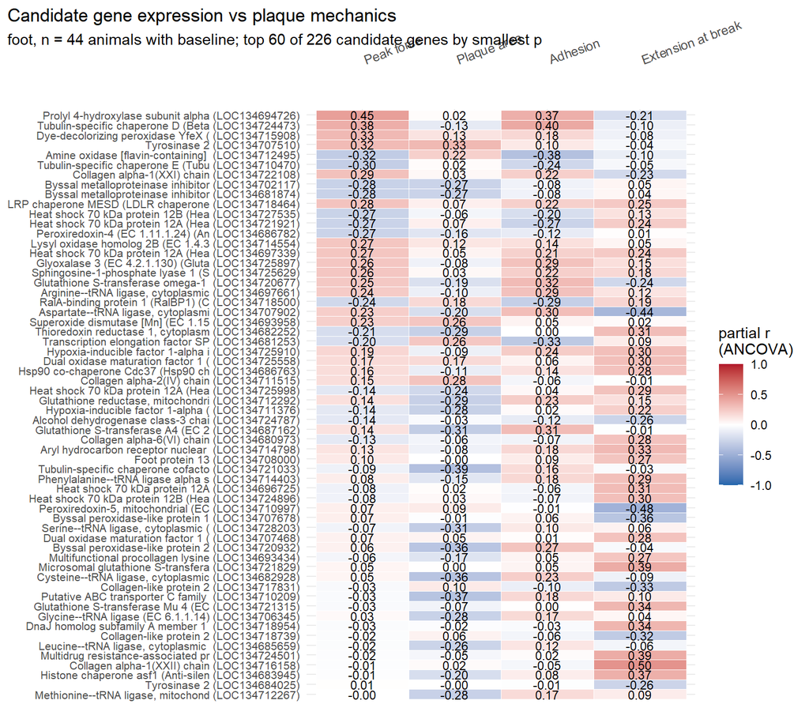

```r
HEATMAP_MAX_GENES <- 60
hm_keep <- res_cand %>% group_by(LOC_ID) %>% summarise(best_p = min(p_lm), .groups = "drop") %>%
  slice_min(best_p, n = HEATMAP_MAX_GENES, with_ties = FALSE) %>% pull(LOC_ID)
hm <- res_cand %>%
  filter(LOC_ID %in% hm_keep) %>%
  mutate(label = paste0(substr(protein_name, 1, 34), " (", LOC_ID, ")")) %>%
  select(label, metric, partial_r) %>%
  pivot_wider(names_from = metric, values_from = partial_r) %>%
  arrange(desc(abs(max_force)))

hm_long <- hm %>% pivot_longer(-label, names_to = "metric", values_to = "r") %>%
  mutate(metric = factor(metric, levels = metrics))
short_label <- function(m) sub(" \\(.*\\)$", "", label_of(m))    # "Peak force (N)" -> "Peak force"
ggplot(hm_long, aes(metric, factor(label, levels = rev(hm$label)), fill = r)) +
  geom_tile(color = "white") +
  geom_text(aes(label = sprintf("%.2f", r)), size = 3) +
  scale_fill_gradient2(low = "#2166AC", mid = "white", high = "#B2182B",
                       midpoint = 0, limits = c(-1, 1)) +
  scale_x_discrete(labels = short_label, position = "top") +
  labs(x = NULL, y = NULL, fill = "partial r\n(ANCOVA)",
       title = "Candidate gene expression vs plaque mechanics",
       subtitle = sprintf("%s, n = %d animals with baseline; top %d of %d candidate genes by smallest p",
                          ifelse(TISSUE == "F", "foot", "gill"), sum(!is.na(paired$base_max_force)),
                          nrow(hm), nrow(candidates))) +
  theme_minimal(base_size = 11) +
  theme(axis.text.y = element_text(size = 8),
        axis.text.x = element_text(size = 9, angle = 20, hjust = 0),
        plot.title.position = "plot")
```

```r
ggsave(file.path(OUT_DIR, sprintf("candidate_heatmap_%s.png", TISSUE)),
       width = 7.5, height = 8.5, dpi = 150, bg = "white")   # theme_minimal has no background: force one
```

## 6.2 Scatterplots for the strongest candidate hits (vs peak force)

The y axis is the day-3 level on the model scale, adjusted to the mean baseline: the residual of `log(level) ~ log(baseline)` plus the grand mean. The reported slopes come from the full ANCOVA (arm and baseline together); this is the display version of the same adjustment, kept free of the arm so that colouring by arm still shows where each arm sits.

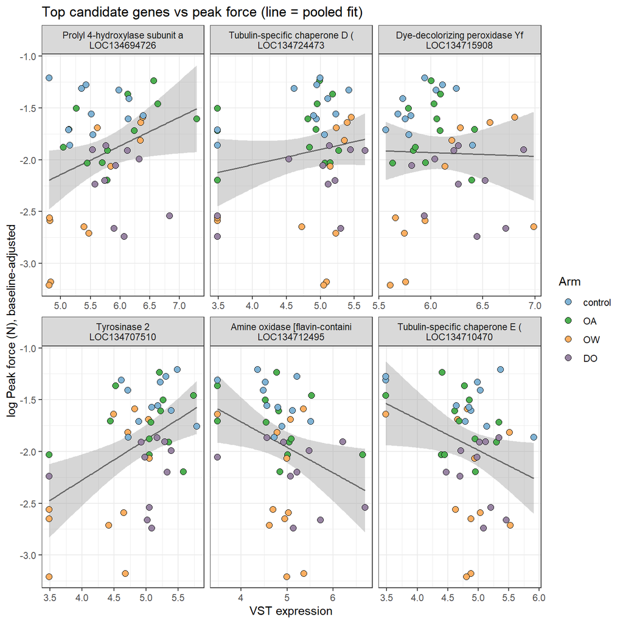

```r
## day-3 level adjusted to the mean baseline, on the metric's model scale (NA without baseline)
adjusted_level <- function(metric) {
  d  <- data.frame(y = on_scale(metric, paired[[metric]]),
                   base = on_scale(metric, paired[[paste0("base_", metric)]]))
  ok <- stats::complete.cases(d)
  out <- rep(NA_real_, nrow(d))
  if (sum(ok) >= 6) out[ok] <- mean(d$y[ok]) + residuals(lm(y ~ base, data = d[ok, ]))
  out
}
adjusted_label <- function(metric)
  sprintf("%s%s, baseline-adjusted", if (scale_of(metric) == "log") "log " else "", label_of(metric))

top_loci <- res_cand %>% filter(metric == "max_force") %>%
  slice_min(p_lm, n = 6, with_ties = FALSE) %>% pull(LOC_ID)

plot_df <- map_dfr(top_loci, function(loc) {
  tibble(LOC_ID = loc,
         protein = annot$protein_name[match(loc, annot$LOC_ID)],
         expr = as.numeric(vp[match(loc, rownames(vp)), paired$sample]),
         y = adjusted_level("max_force"),
         treatment = paired$treatment)
}) %>% filter(!is.na(y)) %>%
  mutate(facet = factor(paste0(substr(protein, 1, 30), "\n", LOC_ID),
                        levels = unique(paste0(substr(protein, 1, 30), "\n", LOC_ID))))

arm_cols <- c(control = "#7FB3D5", OA = "#4CAF50", OW = "#fdae61", DO = "#9884a3")   # shared by 6.2 and 6.3
ggplot(plot_df, aes(expr, y)) +
  geom_smooth(method = "lm", se = TRUE, color = "grey40", linewidth = 0.6) +
  geom_point(aes(fill = treatment), shape = 21, size = 2.4, stroke = 0.5, color = "black") +
  facet_wrap(~ facet, scales = "free_x") +
  scale_fill_manual(values = arm_cols, name = "Arm") +
  labs(x = "VST expression", y = adjusted_label("max_force"),
       title = "Top candidate genes vs peak force (line = pooled fit)") +
  theme_bw(base_size = 11)
```

```r
ggsave(file.path(OUT_DIR, sprintf("top_candidate_scatter_%s.png", TISSUE)),
       width = 9, height = 7, dpi = 150, bg = "white")
```

## 6.3 The strongest candidate hit for each metric, coloured by arm

One panel per metric, the single best candidate gene for that metric, y baseline-adjusted as above. Colouring by arm is the check that matters: an association driven by one arm sitting at one end of both axes is an arm effect, not a gene effect.

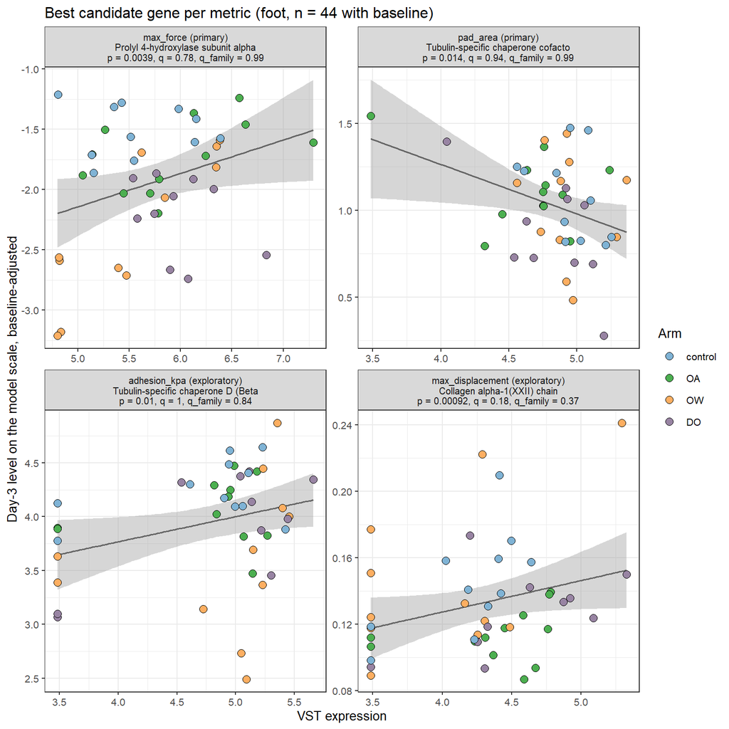

```r
best_per_metric <- res_cand %>%
  mutate(metric = factor(metric, levels = metrics)) %>%
  group_by(metric) %>% slice_min(p_lm, n = 1, with_ties = FALSE) %>% ungroup() %>%
  arrange(metric)

best_df <- pmap_dfr(best_per_metric %>% select(LOC_ID, metric, p_lm, q_lm, q_family),
                    function(LOC_ID, metric, p_lm, q_lm, q_family) {
  m <- as.character(metric)
  tibble(metric = m,
         panel  = sprintf("%s (%s)\n%s\np = %s, q = %s, q_family = %s", m, tier_of(m),
                          substr(annot$protein_name[match(LOC_ID, annot$LOC_ID)], 1, 34),
                          signif(p_lm, 2), signif(q_lm, 2), signif(q_family, 2)),
         expr   = as.numeric(vp[match(LOC_ID, rownames(vp)), paired$sample]),
         y      = adjusted_level(m),
         treatment = paired$treatment)
}) %>% filter(!is.na(y)) %>%
  mutate(panel = factor(panel, levels = unique(panel)))

ggplot(best_df, aes(expr, y)) +
  geom_smooth(method = "lm", se = TRUE, color = "grey40", linewidth = 0.6) +
  geom_point(aes(fill = treatment), shape = 21, size = 2.6, stroke = 0.5, color = "black") +
  facet_wrap(~ panel, scales = "free", ncol = 2) +
  scale_fill_manual(values = arm_cols, name = "Arm") +
  labs(x = "VST expression", y = "Day-3 level on the model scale, baseline-adjusted",
       title = sprintf("Best candidate gene per metric (%s, n = %d with baseline)",
                       ifelse(TISSUE == "F", "foot", "gill"), sum(!is.na(paired$base_max_force)))) +
  theme_bw(base_size = 10) + theme(strip.text = element_text(size = 7.5))
```

```r
ggsave(file.path(OUT_DIR, sprintf("best_hit_per_metric_scatter_%s.png", TISSUE)),
       width = 9, height = 8.5, dpi = 150, bg = "white")
```

# 7. Session info & interpretation notes

**How to read the outputs**

- `assoc_candidate_*.csv` / `assoc_DEGunion_*.csv`: one row per gene x metric from the ANCOVA `level_day3 ~ expression + treatment [+ secretion_state] + level_baseline`. `slope` (with `se`) is the change in the day-3 level per unit VST expression with the arm and the animal’s own baseline held constant: log units for force, area and adhesion, so exp(slope) is the multiplicative change per VST unit; mm for extension. `p_lm` is its t-test; `q_lm` is BH within the gene set x metric and `q_family` BH within the gene set x tier (candidate x primary is the declared confirmatory family); `baseline_slope` is the coefficient on the baseline level; `partial_r` is the same test as a partial correlation.
- A negative slope/partial_r means higher expression goes with *weaker* attachment.

**Caveats baked into the design (do not skip in the manuscript):**

1. Only the paired animals with baseline threads are in the fits, and within-arm n is small. Within-arm correlations are not interpretable on their own; the pooled-with-covariate model borrows strength across arms but confounds arm-level expression shifts with attachment differences.
2. Multiple testing: the candidate set (the keyword matches under the genome-wide map) x PRIMARY_METRICS is the declared confirmatory family (`tier = primary`, `q_family`); the remaining metrics and the DEG-union (hundreds) are exploratory / screening. Quote q beside p, never p alone.
3. Baseline adjustment: the covariate is the animal’s own pre-exposure level, the same summary on the same scale. It absorbs any between-animal baseline differences that the arm assignment did not balance (checked in thread-strength script 3, 3b) without adding the baseline’s measurement noise to the response. Animals without baseline threads are not in the fits.
4. `USE_SECRETION_STATE` (default FALSE) adds the animal’s byssal secretion state (on/off, from differential-expression script 01_7) as a nuisance covariate. It is off by default because the state is itself an expression-derived quantity measured on the same sample; turn it on as a sensitivity analysis when a candidate co-varies with the plaque-protein module (`byssal_structural = TRUE` in candidate_genes_.csv).
5. Destructive sampling: expression and post-stress threads are the same animal/timepoint, so this is contemporaneous association, not a predictive or causal link.
6. `max_force` and `pad_area` are the declared primary metrics; `adhesion_kpa` is their ratio, and a response in plaque area alone can be invisible in it. Read force and area first.
7. With `INCLUDE_CONTROL_ARM = TRUE` the control animals contribute a fourth treatment level. An expression-mechanics association that holds within the control arm as well is about attachment biology in general, not about the stress response; that distinction is worth checking by hand for any top hit (scatter by arm). R version 4.2.2 (2022-10-31 ucrt) Platform: x86_64-w64-mingw32/x64 (64-bit) Running under: Windows 10 x64 (build 26200)

Matrix products: default

locale: [1] LC_COLLATE=English_United States.utf8 [2] LC_CTYPE=English_United States.utf8  
[3] LC_MONETARY=English_United States.utf8 [4] LC_NUMERIC=C  
[5] LC_TIME=English_United States.utf8

attached base packages: [1] stats4 stats graphics grDevices utils datasets methods  
[8] base

other attached packages: [1] forcats_1.0.0 stringr_1.5.0  
[3] dplyr_1.2.0 purrr_1.0.1  
[5] readr_2.1.3 tidyr_1.3.0  
[7] tibble_3.3.1 ggplot2_4.0.2  
[9] tidyverse_1.3.2 here_1.0.1  
[11] openxlsx_4.2.5.2 readxl_1.4.1  
[13] DESeq2_1.38.3 SummarizedExperiment_1.28.0 [15] Biobase_2.58.0 MatrixGenerics_1.10.0  
[17] matrixStats_0.63.0 GenomicRanges_1.50.2  
[19] GenomeInfoDb_1.34.9 IRanges_2.32.0  
[21] S4Vectors_0.36.1 BiocGenerics_0.44.0

loaded via a namespace (and not attached): [1] nlme_3.1-162 bitops_1.0-7 fs_1.6.6  
[4] lubridate_1.9.1 bit64_4.0.5 RColorBrewer_1.1-3  
[7] httr_1.4.5 rprojroot_2.0.3 tools_4.2.2  
[10] backports_1.4.1 bslib_0.10.0 utf8_1.2.3  
[13] R6_2.6.1 otel_0.2.0 mgcv_1.8-41  
[16] DBI_1.1.3 colorspace_2.1-0 withr_3.0.3  
[19] tidyselect_1.2.1 bit_4.0.5 compiler_4.2.2  
[22] textshaping_0.3.6 rvest_1.0.3 cli_3.6.5  
[25] xml2_1.5.2 DelayedArray_0.24.0 labeling_0.4.3  
[28] sass_0.4.10 scales_1.4.0 S7_0.2.1  
[31] systemfonts_1.0.4 digest_0.6.31 rmarkdown_2.20  
[34] XVector_0.38.0 dichromat_2.0-0.1 pkgconfig_2.0.3  
[37] htmltools_0.5.9 dbplyr_2.3.1 fastmap_1.2.0  
[40] rlang_1.1.7 rstudioapi_0.14 RSQLite_2.2.20  
[43] jquerylib_0.1.4 farver_2.1.1 generics_0.1.4  
[46] jsonlite_2.0.0 vroom_1.6.1 BiocParallel_1.32.5  
[49] zip_2.2.2 googlesheets4_1.0.1 RCurl_1.98-1.10  
[52] magrittr_2.0.3 GenomeInfoDbData_1.2.9 Matrix_1.5-3  
[55] Rcpp_1.0.10 lifecycle_1.0.5 stringi_1.7.12  
[58] yaml_2.3.7 zlibbioc_1.44.0 grid_4.2.2  
[61] blob_1.2.3 parallel_4.2.2 crayon_1.5.2  
[64] lattice_0.20-45 splines_4.2.2 Biostrings_2.66.0  
[67] haven_2.5.1 annotate_1.76.0 hms_1.1.2  
[70] KEGGREST_1.38.0 locfit_1.5-9.7 knitr_1.51  
[73] pillar_1.11.1 geneplotter_1.76.0 codetools_0.2-19  
[76] reprex_2.0.2 XML_3.99-0.13 glue_1.8.0  
[79] evaluate_1.0.5 modelr_0.1.10 tzdb_0.3.0  
[82] png_0.1-8 vctrs_0.7.1 cellranger_1.1.0  
[85] gtable_0.3.6 cachem_1.1.0 xfun_0.56  
[88] xtable_1.8-4 broom_1.0.3 ragg_1.2.5  
[91] googledrive_2.0.0 gargle_1.3.0 AnnotationDbi_1.60.0  
[94] memoise_2.0.1 timechange_0.2.0 ellipsis_0.3.2

# 8. Provenance

`RUN_provenance_<T>.txt` records the configuration behind every file in `03_analyses/gene_mechanics/` (the thread-strength scripts keep the same kind of file), and the git commit that last touched the thread input, so a result can always be traced to the thread table it was computed from. Script 21 appends its own block.

```r
git_last_commit <- function(path) {
  ## guarded: no git, not a repo, or an untracked file all yield "unavailable"
  if (!nzchar(Sys.which("git")) || !file.exists(path)) return("unavailable")
  out <- tryCatch(suppressWarnings(
           system2("git", c("-C", shQuote(dirname(path)), "log", "-n", "1",
                            shQuote("--format=%h %cs"), "--", shQuote(basename(path))),
                   stdout = TRUE, stderr = FALSE)),
         error = function(e) character(0))
  if (length(out) == 0 || !is.null(attr(out, "status")) || !nzchar(out[1])) "unavailable" else out[1]
}
prov <- file.path(OUT_DIR, sprintf("RUN_provenance_%s.txt", TISSUE))
writeLines(c(
  "[20-gene_mechanics_correlation.Rmd]",
  paste0("generated            : ", format(Sys.time(), "%Y-%m-%d %H:%M:%S")),
  paste0("tissue               : ", TISSUE),
  paste0("thread input         : ", THREAD_FILE),
  paste0("thread input commit  : ", git_last_commit(THREAD_FILE)),
  paste0("response input       : ", RESPONSE_FILE, " (", ifelse(file.exists(RESPONSE_FILE), "present", "absent"), ")"),
  paste0("count matrix         : ", file.path(DE_DIR, "02_data", "gene_count_matrix_clean.csv")),
  paste0("INCLUDE_CONTROL_ARM  : ", INCLUDE_CONTROL_ARM),
  paste0("USE_SECRETION_STATE  : ", USE_SECRETION_STATE),
  paste0("reported test        : ANCOVA level_day3 ~ expression + ", paste(COVARIATES, collapse = " + "),
         " + level_baseline (per-animal geometric mean, log scale; extension raw)"),
  paste0("metrics [scale, tier]: ", paste(sprintf("%s [%s, %s]", METRICS$metric, METRICS$scale, METRICS$tier),
                                          collapse = ", ")),
  paste0("PRIMARY_METRICS      : ", paste(PRIMARY_METRICS, collapse = ", ")),
  paste0("MIN_COUNT / FDR_ALPHA: ", MIN_COUNT, " / ", FDR_ALPHA),
  paste0("paired animals       : ", nrow(paired), " (", paste(sprintf("%s %d", names(table(paired$treatment)),
                                                                     as.integer(table(paired$treatment))), collapse = ", "), ")"),
  paste0("with baseline (in fits): ", sum(!is.na(paired$base_max_force)), " (",
         paste(sprintf("%s %d", names(table(paired$treatment[!is.na(paired$base_max_force)])),
                       as.integer(table(paired$treatment[!is.na(paired$base_max_force)]))), collapse = ", "), ")"),
  paste0("genes tested         : ", nrow(vp)),
  paste0("CANDIDATE_ANNOTATION : ", CANDIDATE_ANNOTATION, " (evalue <= ", CANDIDATE_MAX_EVALUE,
         ", pident >= ", CANDIDATE_MIN_PIDENT, ")"),
  paste0("annotation map       : ", nrow(annot), " LOCs (", MASTER_ANNOT_FILE, ")"),
  paste0("candidate genes      : ", nrow(candidates), " (byssal structural ", sum(candidates$byssal_structural),
         "; named in TC DEG tables ", sum(candidates$in_TC_DEG_annotation), ")"),
  paste0("EXCLUDE_FLOOR_GENES  : ", EXCLUDE_FLOOR_GENES, " (exclude > ", FLOOR_EXCLUDE, ", caution > ", FLOOR_CAUTION, ")"),
  paste0("candidates tested    : ", sum(candidates$tested), " (", sum(!candidates$tested), " at the detection floor)"),
  paste0("DEG union tested     : ", sum(deg_union_tbl$tested), " of ", nrow(deg_union_tbl)),
  paste0("DEG union genes      : ", length(deg_union)),
  paste0("R / DESeq2           : ", R.version.string, " / ", as.character(packageVersion("DESeq2")))),
  prov)
cat(readLines(prov), sep = "\n")
```

```
## [20-gene_mechanics_correlation.Rmd]
## generated            : 2026-09-29 22:13:35
## tissue               : F
## thread input         : C:/Users/mattg/Desktop/github/PSMFC-mytilus-byssus-pilot/thread-strength/03_analyses/thread-summary.xlsx
## thread input commit  : 0a8a836 2026-09-29
## response input       : C:/Users/mattg/Desktop/github/PSMFC-mytilus-byssus-pilot/thread-strength/03_analyses/04_decompose-adhesion/mussel_response_classification.csv (present)
## count matrix         : C:/Users/mattg/Desktop/github/PSMFC-mytilus-byssus-pilot/differential-expression/02_data/gene_count_matrix_clean.csv
## INCLUDE_CONTROL_ARM  : TRUE
## USE_SECRETION_STATE  : FALSE
## reported test        : ANCOVA level_day3 ~ expression + treatment + level_baseline (per-animal geometric mean, log scale; extension raw)
## metrics [scale, tier]: max_force [log, primary], pad_area [log, primary], adhesion_kpa [log, exploratory], max_displacement [raw, exploratory]
## PRIMARY_METRICS      : max_force, pad_area
## MIN_COUNT / FDR_ALPHA: 5 / 0.1
## paired animals       : 45 (control 11, OA 12, OW 12, DO 10)
## with baseline (in fits): 44 (control 11, OA 12, OW 11, DO 10)
## genes tested         : 10090
## CANDIDATE_ANNOTATION : genome (evalue <= 1e-10, pident >= 0)
## annotation map       : 16675 LOCs (C:/Users/mattg/Desktop/github/PSMFC-mytilus-byssus-pilot/blast/03_analyses/genome-foot/LOC_GO_list.txt)
## candidate genes      : 226 (byssal structural 17; named in TC DEG tables 57)
## EXCLUDE_FLOOR_GENES  : TRUE (exclude > 0.4, caution > 0.2)
## candidates tested    : 201 (25 at the detection floor)
## DEG union tested     : 520 of 523
## DEG union genes      : 523
## R / DESeq2           : R version 4.2.2 (2022-10-31 ucrt) / 1.38.3
```